# Unit 1 R Markdown

### barplot

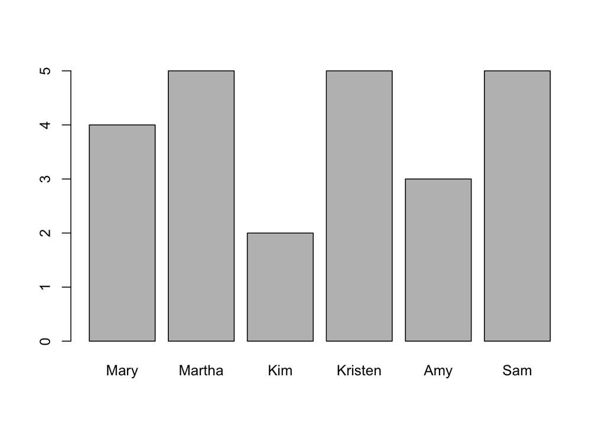

```r
age = c(22,21,24,19,20,23)
yrs_math_ed = c(4,5,2,5,3,5)
names = c("Mary","Martha","Kim","Kristen","Amy","Sam")
subject = c("English","Math","Sociology","Math","Music","Dance")
df3 = data.frame(Age = age, Years = yrs_math_ed, Name = names, Subject = subject)
barplot(df3$Years, names.arg = df3$Name)
```

### We want a barplot of frequency of each class of car.

###note here how the data is in a different format for mpg. ###it is not one row per relevant observation with the value at the end ###we need to actually count the number of each class and then plot

### We could count … that would take a while

### We could turn class into a factor and then let summary count for us.

```r
summary(mpg$class)
```

```
##    Length     Class      Mode
##       234 character character
```

```r
mpg$classFact = as.factor(mpg$class)
head(mpg)
```

```
## # A tibble: 6 x 12
##   manufacturer model displ  year   cyl trans drv     cty   hwy fl    class
##   <chr>        <chr> <dbl> <int> <int> <chr> <chr> <int> <int> <chr> <chr>
## 1 audi         a4      1.8  1999     4 auto… f        18    29 p     comp…
## 2 audi         a4      1.8  1999     4 manu… f        21    29 p     comp…
## 3 audi         a4      2    2008     4 manu… f        20    31 p     comp…
## 4 audi         a4      2    2008     4 auto… f        21    30 p     comp…
## 5 audi         a4      2.8  1999     6 auto… f        16    26 p     comp…
## 6 audi         a4      2.8  1999     6 manu… f        18    26 p     comp…
## # … with 1 more variable: classFact <fct>
```

```r
summary(mpg$classFact)
```

```
##    2seater    compact    midsize    minivan     pickup subcompact        suv
##          5         47         41         11         33         35         62
```

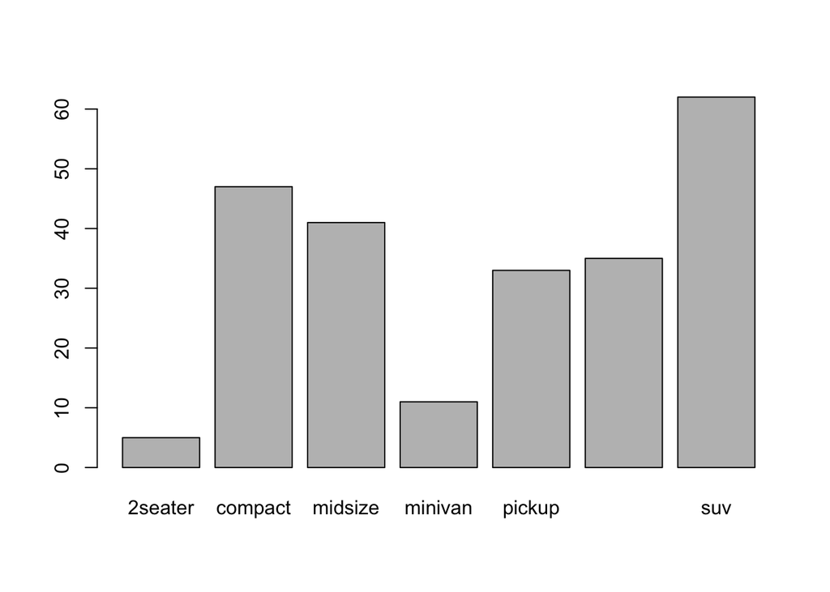

```r
barplot(summary(mpg$classFact))
```

# UNIT 1 R Review Part 3.R

## Statistics in R

### Sampling Distribution of the Individual

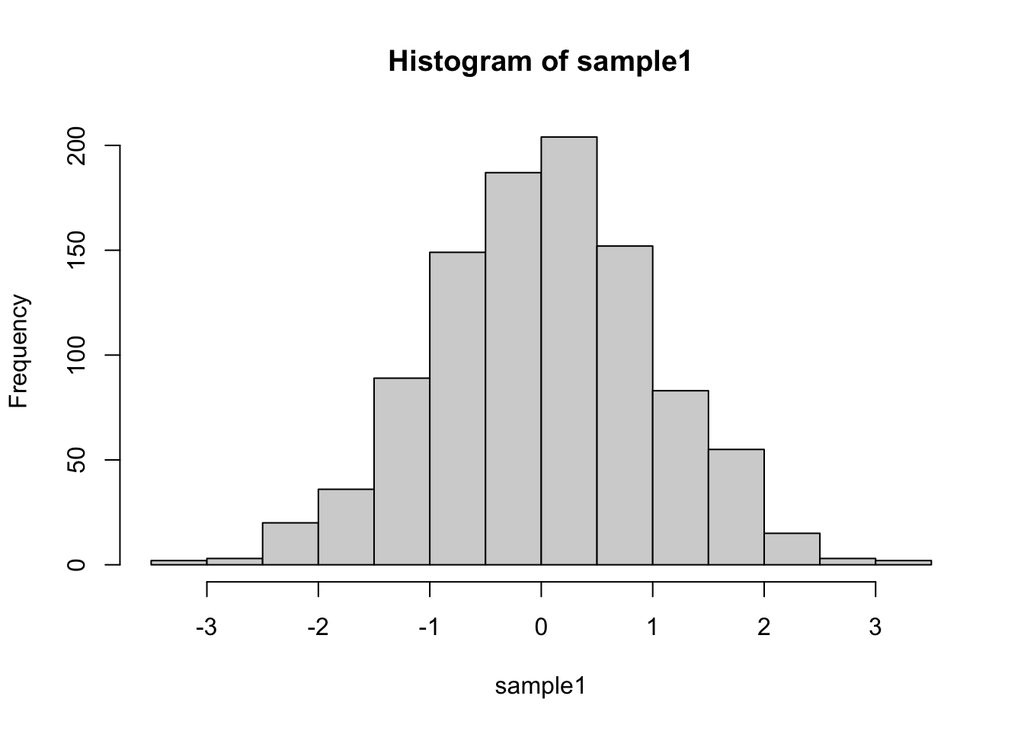

```r
#draw a sample from a standard normal distribution
#run many times varying sample size and look at histogram and mean
sample1 = rnorm(1000,0,1)
hist(sample1)
```

```r
mean(sample1)
```

```
## [1] 0.01567186
```

```r
sd(sample1)
```

```
## [1] 0.9892457
```

### Another way to code the same thing

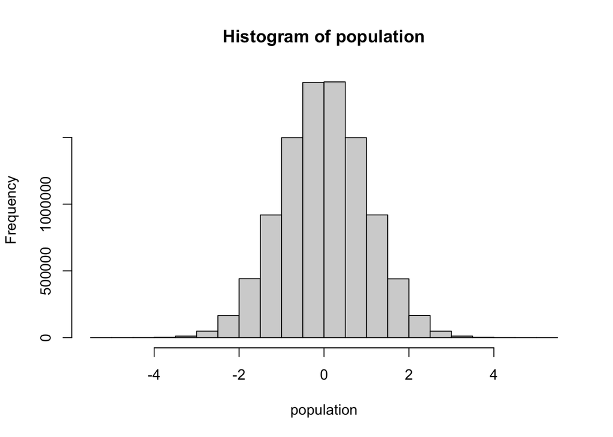

```r
population = rnorm(10000000,0,1) #note the the number of draws here
hist(population)
```

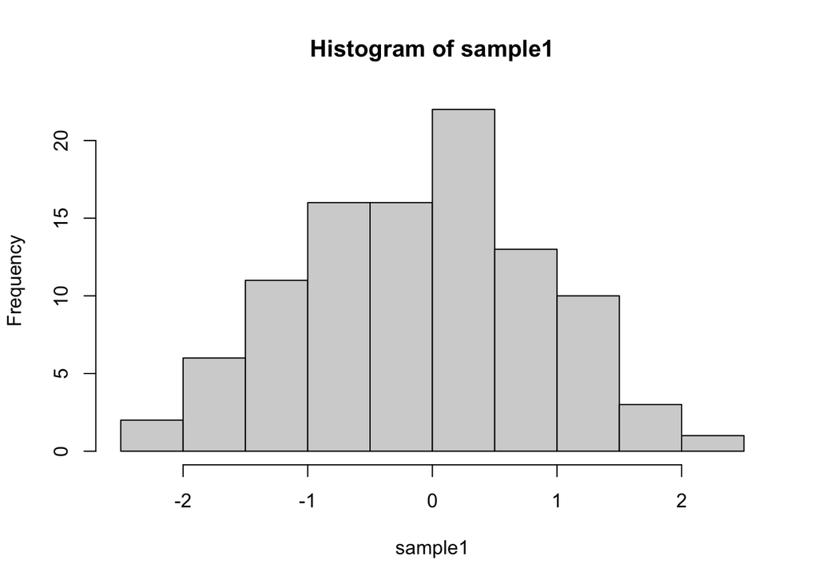

```r
sample1 = sample(population,100) #sample of size 100
hist(sample1)
```

```r
mean(sample1)
```

```
## [1] -0.07243987
```

```r
sd(sample1)
```

```
## [1] 0.9436001
```

### Sampling Distribution of the Sample Mean

now make a function in which you pass the sample size, the number of samples to take #and thus the number of sample means to return as well as the mean and sd.

Define these outside the function so that they exist outside the function (global)

```r
xBarVec = c() #Global vector to hold the sample means
population = rnorm(10000000,0,1) #Simulating the population
```

### The Function

```r
#####################################################
# Funciton: xbarGenerator
# Argements: samplesize: the size of the sample that each sample mean is based on.
#            number_of_samples: the number of samples and thus sample means we will generate
# Author: Bivin Sadler
#####################################################
xbarGenerator = function(sampleSize = 30,number_of_samples = 100)
{
  for(i in 1:number_of_samples)
  {
    theSample = sample(population,sampleSize)
    xbar = mean(theSample)
    xBarVec = c(xBarVec, xbar)
  }
  return(xBarVec)
}
```

### Before you Run This…. What do you think will be the “Sampleing Distribution of the Sample Mean”?

```r
xbars = xbarGenerator(30,1000)
length(xbars)
```

```
## [1] 1000
```

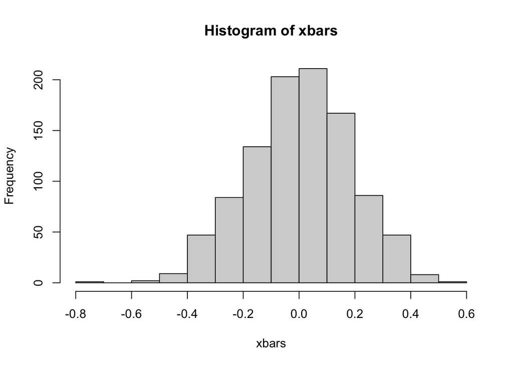

```r
hist(xbars)
```

## You Try It

Now adapt the code above to generate a specified number of sample means of a specified size sample size (this has already been done) from a normally distributed population with a specified meanand standard deviation (currently it is forced to be from a standard normal distribuion N(0,1)).

What is the shape of the distribuion? What is the mean and sd? What should they be given the Central Limit Theorem (CLT). For a refresher of the CLT see the Stats Bridge Course!

### Possibe Solution

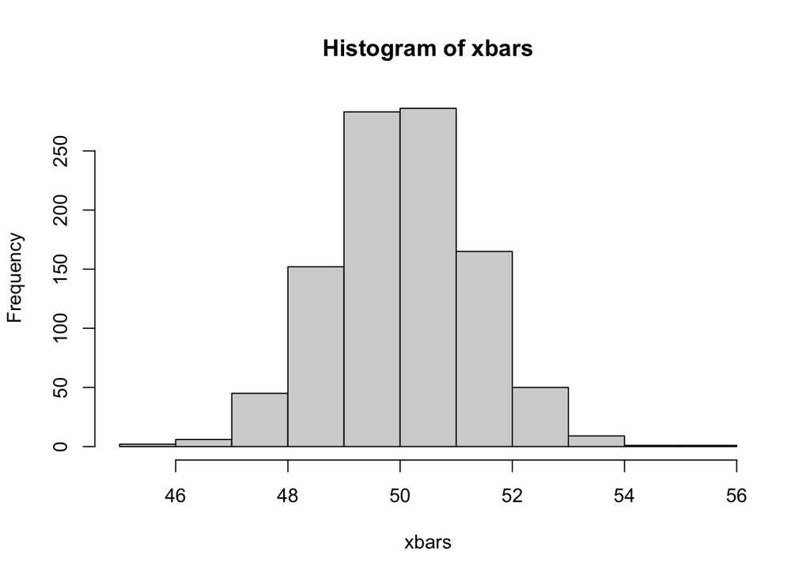

```r
xBarVec = c() #global vector to hold the sample means
#####################################################
# Funciton: xbarGenerator (Adpated)
# Argements: samplesize: the size of the sample that each sample mean is based on.
#            number_of_samples: the number of samples and thus sample means we will generate
# Author: Bivin Sadler
#####################################################
xbarGenerator2 = function(sampleSize = 30,number_of_samples = 100, mean = 0, sd = 1)
{
  for(i in 1:number_of_samples)
  {
    theSample = rnorm(sampleSize,mean,sd)
    xbar = mean(theSample)
    xBarVec = c(xBarVec, xbar)
  }
  return(xBarVec)
}
xbars = xbarGenerator2(60,1000,50,10)
hist(xbars)
```

```r
summary(xbars)
```

```
##    Min. 1st Qu.  Median    Mean 3rd Qu.    Max.
##   45.50   49.16   50.04   50.04   50.93   55.28
```

```r
sd(xbars)
```

```
## [1] 1.275084
```

```r
10/sqrt(60)
```

```
## [1] 1.290994
```